# Spotlight Index

|Martínez Contreras Guillermo Alfonso |Ramírez Almanza Ana Samantha |Torres Hernández Mariano

23 de octubre de 2018

## Introducción

Un buen comienzo es entender el mercado de capitales el cual es un tipo de mercado financiero donde se realiza la compra-venta de títulos valor, activos financieros de empresas y otras unidades económicas como son las acciones, obligaciones y títulos de deuda a largo plazo.

El mercado de capitales otorga a los inversores la posibilidad de participar como socios proporcionalmente en el capital de la empresa invertido. En contraposición, las empresas tienen la posibilidad de colocar parte de su capital entre un gran número de inversores con el propósito de financiar capital de trabajo y la expansión de la empresa.

Existen muchos ejemplos por conocer y desarrollar en el área de Capitales con ayuda de Ciencias de la Computación y Ciencia de Datos. Desde la automatización de procesos básicos de valuación diaria, hasta la investigación/estrategia de mercado y el aprendizaje automático para la toma de decisiones. Sin embargo, conforme aumenta el nivel de posibilidades, aumenta también el riesgo. Debido a la complejidad en los mercados, la variedad de instrumentos y la cantidad de información disponible, es importante que los modelos que se realicen tengan en consideración, no solo los rendimientos y la optimización, también los riesgos implícitos tanto para la inversión que se está diseñando, como para los agentes externos.

En el Mercado de Capitales no existe un contexto único, aunque frecuentemente se analiza con base en tipo de instrumentos (corto o largo plazo, renta fija o variable), también puede analizarse desde la perspectiva de organización del mercado (OTC o regulado) o del punto de ejecución de la inversión (mercado primario durante la emisión, o mercado secundario). Para cualquiera de los casos anteriores podemos utilizar datos como indices, precios, tasas, medidas de sensibilidad, calificaciones, y rendimientos, entre otros.. mismos que requieren de valuaciones donde el tiempo y la incertidumbre son factores fundamentales. Los cambios en estos datos dentro del Mercado de Capitales pueden darse por día, hora, minutos e incluso segundos (depende del tipo de instrumento y la liquidez del mercado).

Es importante conocer algunos conceptos clave para nuestro proyecto:

**Índice temático:** El objetivo es identificar tendencias sociales, económicas, industriales, ambientales o demográficas específicas y sus influencias seculares, cíclicas y estructurales a largo plazo en las economías y mercados mundiales por medio de deferentes sectores, de tal manera que a través de un índice financiero podemos explicar el comportamiento de un sub-sector de nuestro interés.

**Backtesting:** Se refiere a una metodología que se utiliza para verificar y diagnosticar la eficiencia y los resultados de un modelo en particular. Esta metodología intenta determinar si las conclusiones del modelo o los cálculos de las variables estimadas son acertadas. Como su nombre lo indica, backtesting significa evaluar hacia atrás, por esta razón, el principal objetivo es saber cuáles habrían sido las conclusiones de un modelo en periodos anteriores y compararlo con datos históricos.

**Fondo Índice:** es un fondo de inversión de renta fija o variable que trata de replicar el comportamiento de un determinado índice del mercado, como pueden ser por ejemplo el IBEX 35, el Eurostoxx 50, el Nikkei 225 o el S&P 500 o también una determinada cesta de valores, dentro de renta variable o algún tipo de interés de referencia en el caso de renta fija. Los fondos índices llevan una gestión pasiva, es decir, replican la composición del indicador (benchmark) que tienen como referencia, sin que los gestores tomen decisiones relativas a la ponderación de los valores que se incluyen dentro del fondo o los sectores preferidos. La principal ventaja de este tipo de fondos es que las comisiones de gestión son inferiores a las del resto de fondos que mantienen una gestión activa.

**Benchmark:** El benchmark es un punto de referencia utilizado para medir el rendimiento de una inversión. Se trata de un indicador financiero utilizado como herramienta de comparación para evaluar el rendimiento de una inversión.

**Inversión Pasiva**: La inversión pasiva es una estrategia de inversión para maximizar los rendimientos al minimizar la compra y venta, es decir, significa comprar un valor con la intención de poseerlo a largo plazo.

**Nivel de Bursatilidad:** El Índice de bursatilidad es un indicador de la Bolsa Mexicana de Valores que mide el nivel de bursatilidad de cada serie accionaria. Los elementos básicos para la elaboración de este índice son el importe operado, el número de operaciones y el importe representativo. El índice de bursatilidad es calculado de manera mensual.

**Métricas de Riesgo** Las métricas de riesgo típicamente toman una de tres formas:

- los que cuantifican la exposición;
- los que cuantifican la incertidumbre;
- Los que cuantifican la exposición y la incertidumbre de alguna manera combinada.

RiskMetrics es una metodología que contiene técnicas y conjuntos de datos utilizados para calcular el valor en riesgo (VaR) de una cartera de inversiones. El objetivo de RiskMetrics es promover y mejorar la transparencia de los riesgos del mercado, crear un punto de referencia para medir el riesgo y brindar asesoramiento a los clientes sobre la gestión de los riesgos del mercado.

**Value at Risk:** El VaR es un método para cuantificar el riesgo. En términos formales, el VaR mide la máxima pérdida esperada en un intervalo de tiempo determinado, bajo condiciones normales del mercado y ante un nivel de confianza dado.

## Etapas de Trabajo (Minería de Datos)

Recordemos que la minería de datos es el conjunto de técnicas y tecnologías que permiten explorar grandes bases de datos con el objetivo de encontrar patrones repetitivos, tendencias o reglas que expliquen el comportamiento de los datos en un determinado contexto.

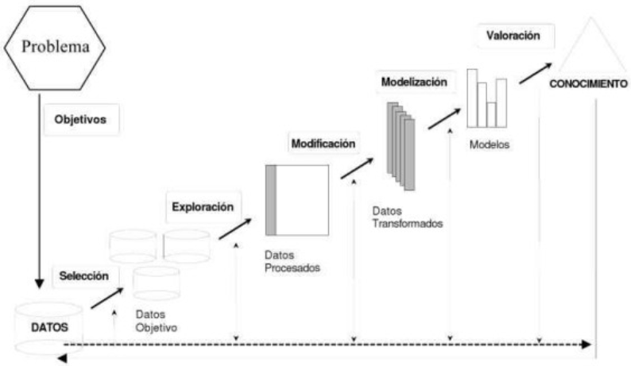

1. **Determinación de los objetivos:** delimitación de los objetivos.
2. **Preprocesamiento de los datos:** se refiere a la selección, la limpieza, el enriquecimiento, la reducción y la transformación de las bases de datos.
3. **Determinación del modelo:** se comienza realizando análisis estadístico de los datos, y después se lleva a cabo una visualización gráfica de los mismos para tener una primera aproximación. Según los objetivos planteados y la tarea que debe llevarse a cabo, se plantea el modelo a seguir.
4. **Análisis de los resultados:** verificamos si los resultados obtenidos son coherentes y los cotejamos con los obtenidos por los análisis estadísticos y de visualización gráfica. A partir de esto determinamos si nuestro modelo aporta la información necesaria para la toma de desiciones.

### 1.Objetivo

Nuestro objetivo es crear un índice temático a través de la construcción de una cartera utilizando las vistas de la página de cada empresa mediante wikipedia. El índice temático debe tener una cesta de acciones que se ponderará teniendo en cuenta el número de visitas que una empresa tiene a lo largo del tiempo.

Nuestra estrategia se realizará con un período de rebalanceo semanal-mensual a partir del 2015 hasta 2018.

### 2. Preprocesamiento de los datos

A continuación, se muestra la selección y limpieza de nuestros datos S&P500 al igual que los views y fechas para cada ticker.

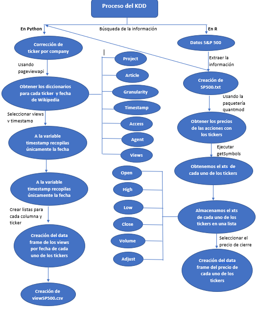

```r
#Datos S&P 500
url_1<-'https://www.slickcharts.com/sp500'
datos<- url_1 %>%
  read_html() %>%
  html_nodes("table") %>%
  html_table()
SP500<-do.call(rbind.data.frame, datos) %>%
  select("Company","Symbol")

#Documento guardato en .txt
write.table(SP500,file ='C:/Users/alman/Documents/Actuaría/9no Semestre/Seminario de Ciencia de Datos en el Mercado de Capitales/Project/bases de datos/SP500.txt',sep = '\t',row.names = FALSE )

#construcción de data frame
#usando la paquetería quantmod se pueden obtener los precios de las acciones
#con los tickers ya obtenidos se utiliará la función getSymbols para obtener
#los precios de cada ticker de la página de yahoo finance algo importante a realizar
#es cambiar los '.' por '-' ya que yahoo finance reconoce el ticker
#'BRK.B' como 'BRK-B'

SP500_Ticker<-sub('.','-',SP500$Symbol,fixed = TRUE)

#al ejecutar getSymbols se obtienen un objeto de tipo xts con las columnas
#Open, High, Low, Close, Volume, Adjust
#este for lo que realiza es obtener el xts de cada uno de los tickers
for (tk in SP500_Ticker) {
  safely(getSymbols(tk,from="2015-01-02"))
}

#declaración la lista donde se almacenará cada uno de los xts
all_stocks<-list()

#al usar la función getSymbols los valores son guardados en el Global ENvironment
#por lo que con ayuda del cliclo for y la función get se van almacendo en la lista
#previamente declarada
for (i in 1:length(SP500_Ticker)) {
  all_stocks[i]<-list(get(SP500_Ticker[i]))
}

#Se selecciona el precio de cierre de cada uno de los tickers con la función Cl
all_stocks <- lapply(all_stocks, Cl)

#dataframe de cada uno de los precios del ticker
stock_data<- as.matrix(Reduce("cbind", all_stocks))
```